# korr_bildungsabschluesse_erkennen

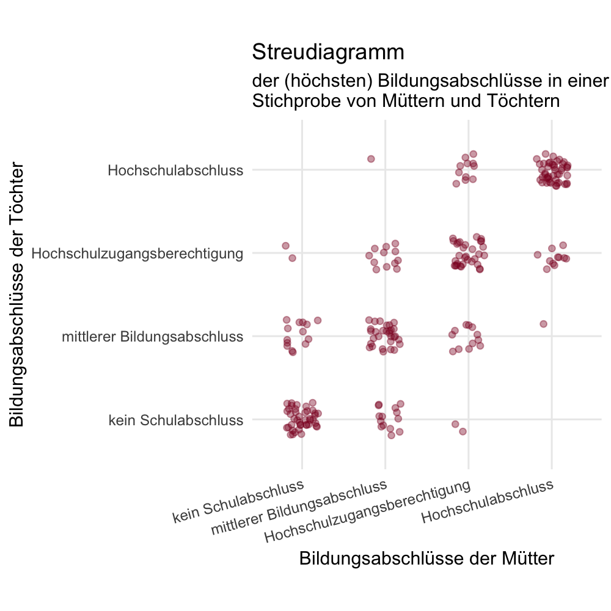

Angenommen ein Forscherteam erhebt in einem Land querschnittlich die höchsten Bildungsabschlüsse von 230 Müttern und deren ältesten Töchter und erhält die oben dargestellten Daten. Welche der folgenden Aussagen können anhand der Daten geschlussfolgert werden?

Die Bildungsabschlüsse der Mütter und der Töchter sind stark positiv korreliert.Die Bildungsabschlüsse der Mütter und der Töchter zeigen keine Assoziation.Die Bildungsabschlüsse der Väter und der Töchter sind schwach negativ korreliert.Höhere Bildung der Mütter **verursacht** höhere Bildung bei den Töchternz.Höhere Bildung der Väter **verursacht** niedrigere Bildung bei den Töchtern.

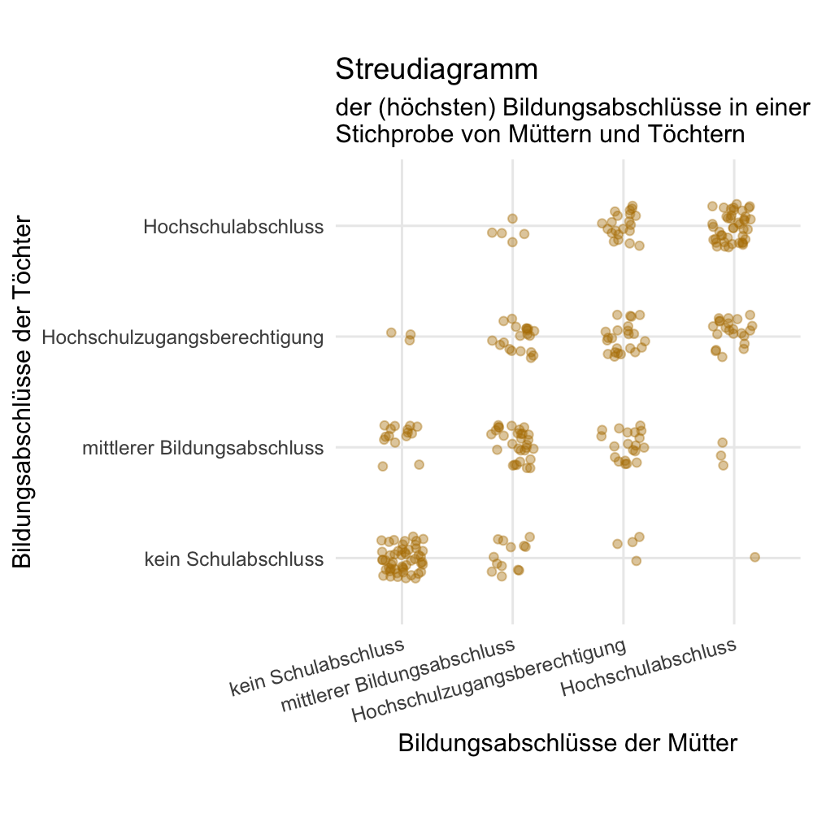

Angenommen ein Forscherteam erhebt in einem Land querschnittlich die höchsten Bildungsabschlüsse von 274 Müttern und deren ältesten Töchter und erhält die oben dargestellten Daten. Welche der folgenden Aussagen können anhand der Daten geschlussfolgert werden?

Die Bildungsabschlüsse der Mütter und der Töchter sind stark positiv korreliert.Die Bildungsabschlüsse der Mütter und der Töchter zeigen keine Assoziation.Die Bildungsabschlüsse der Väter und der Töchter sind schwach negativ korreliert.Höhere Bildung der Mütter **verursacht** höhere Bildung bei den Töchternz.Höhere Bildung der Väter **verursacht** niedrigere Bildung bei den Töchtern.

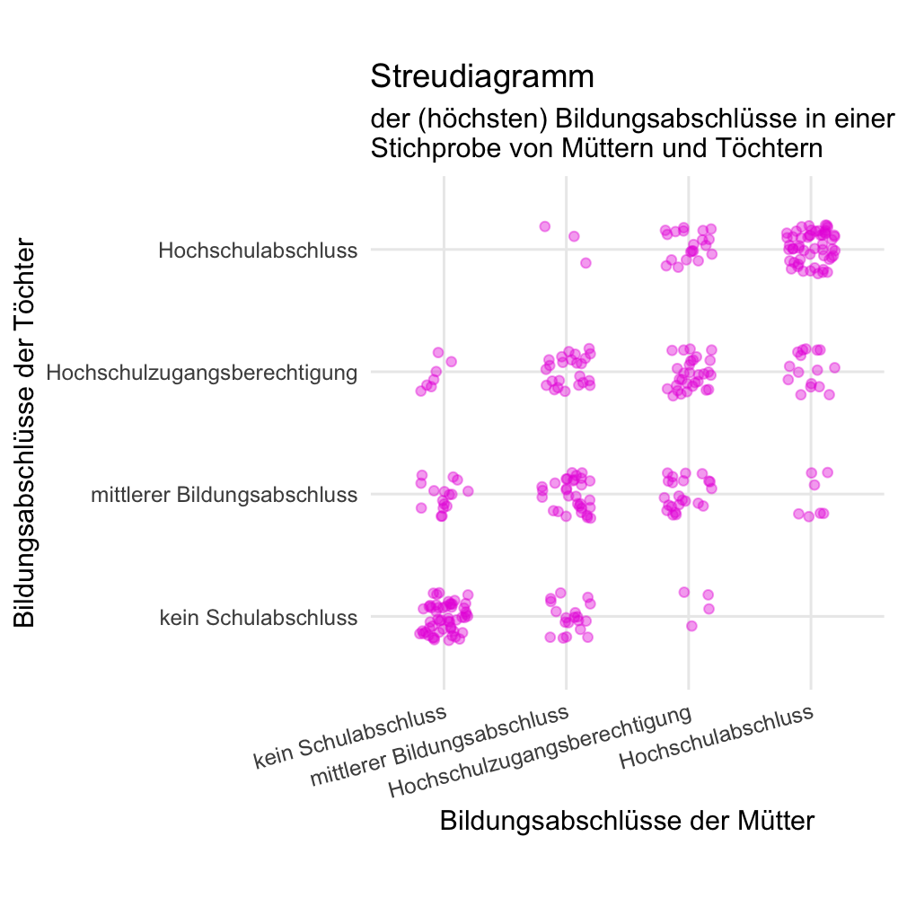

Angenommen ein Forscherteam erhebt in einem Land querschnittlich die höchsten Bildungsabschlüsse von 308 Müttern und deren ältesten Töchter und erhält die oben dargestellten Daten. Welche der folgenden Aussagen können anhand der Daten geschlussfolgert werden?

Die Bildungsabschlüsse der Mütter und der Töchter sind stark positiv korreliert.Die Bildungsabschlüsse der Mütter und der Töchter zeigen keine Assoziation.Die Bildungsabschlüsse der Väter und der Töchter sind schwach negativ korreliert.Höhere Bildung der Mütter **verursacht** höhere Bildung bei den Töchternz.Höhere Bildung der Väter **verursacht** niedrigere Bildung bei den Töchtern.

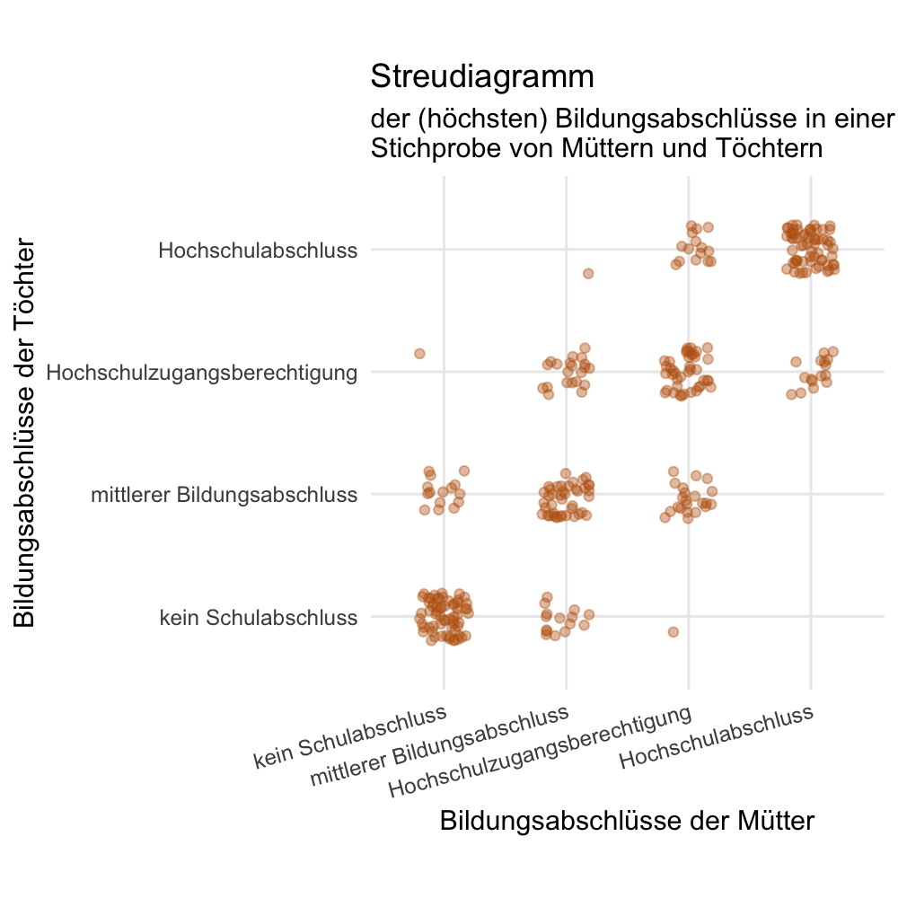

Angenommen ein Forscherteam erhebt in einem Land querschnittlich die höchsten Bildungsabschlüsse von 318 Müttern und deren ältesten Töchter und erhält die oben dargestellten Daten. Welche der folgenden Aussagen können anhand der Daten geschlussfolgert werden?

Die Bildungsabschlüsse der Mütter und der Töchter sind stark positiv korreliert.Die Bildungsabschlüsse der Mütter und der Töchter zeigen keine Assoziation.Die Bildungsabschlüsse der Väter und der Töchter sind schwach negativ korreliert.Höhere Bildung der Mütter **verursacht** höhere Bildung bei den Töchternz.Höhere Bildung der Väter **verursacht** niedrigere Bildung bei den Töchtern.

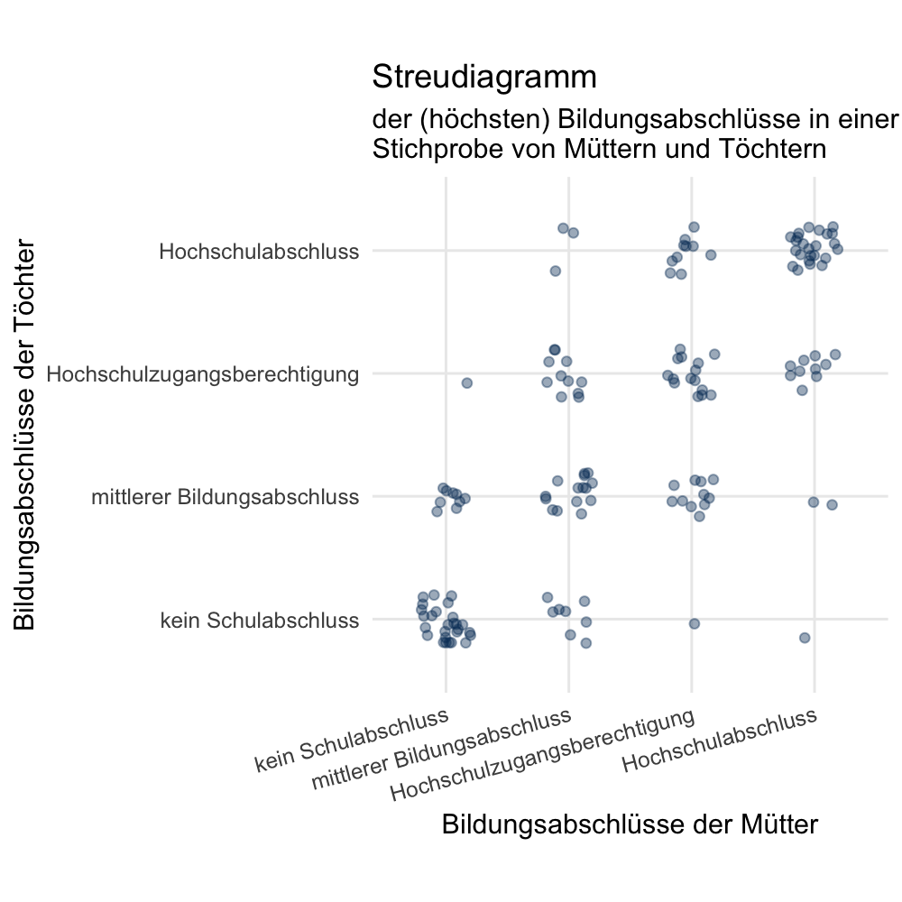

Angenommen ein Forscherteam erhebt in einem Land querschnittlich die höchsten Bildungsabschlüsse von 148 Müttern und deren ältesten Töchter und erhält die oben dargestellten Daten. Welche der folgenden Aussagen können anhand der Daten geschlussfolgert werden?

Die Bildungsabschlüsse der Mütter und der Töchter sind stark positiv korreliert.Die Bildungsabschlüsse der Mütter und der Töchter zeigen keine Assoziation.Die Bildungsabschlüsse der Väter und der Töchter sind schwach negativ korreliert.Höhere Bildung der Mütter **verursacht** höhere Bildung bei den Töchternz.Höhere Bildung der Väter **verursacht** niedrigere Bildung bei den Töchtern.

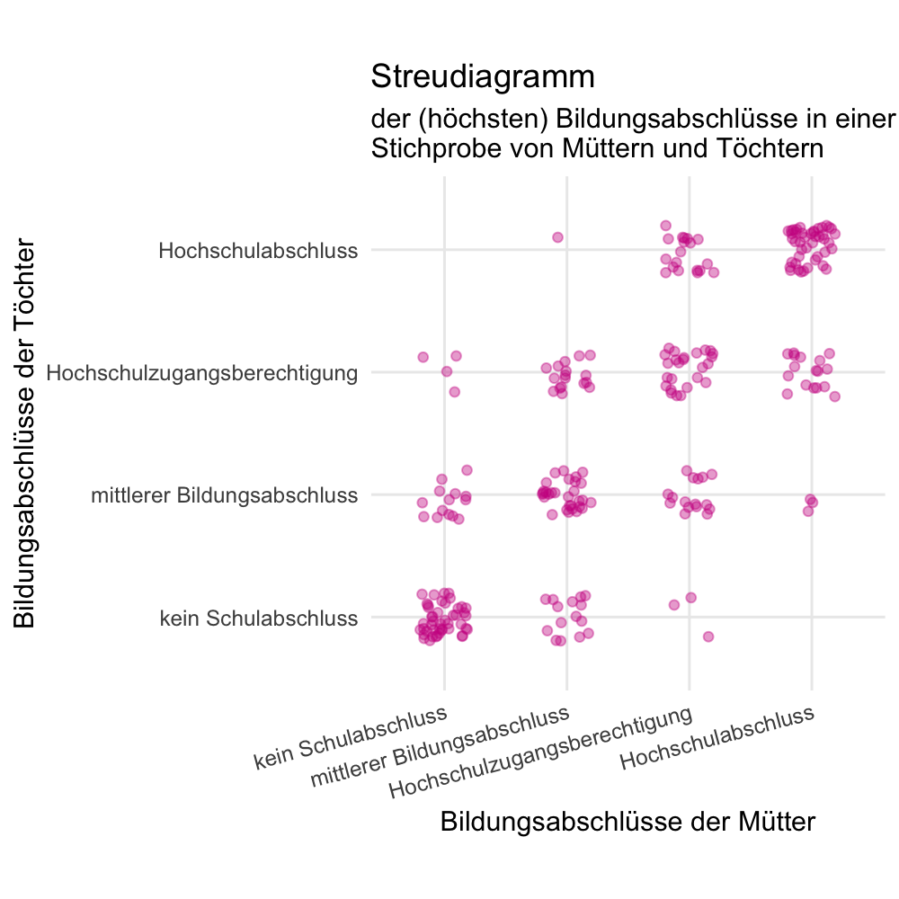

Angenommen ein Forscherteam erhebt in einem Land querschnittlich die höchsten Bildungsabschlüsse von 254 Müttern und deren ältesten Töchter und erhält die oben dargestellten Daten. Welche der folgenden Aussagen können anhand der Daten geschlussfolgert werden?

Die Bildungsabschlüsse der Mütter und der Töchter sind stark positiv korreliert.Die Bildungsabschlüsse der Mütter und der Töchter zeigen keine Assoziation.Die Bildungsabschlüsse der Väter und der Töchter sind schwach negativ korreliert.Höhere Bildung der Mütter **verursacht** höhere Bildung bei den Töchternz.Höhere Bildung der Väter **verursacht** niedrigere Bildung bei den Töchtern.

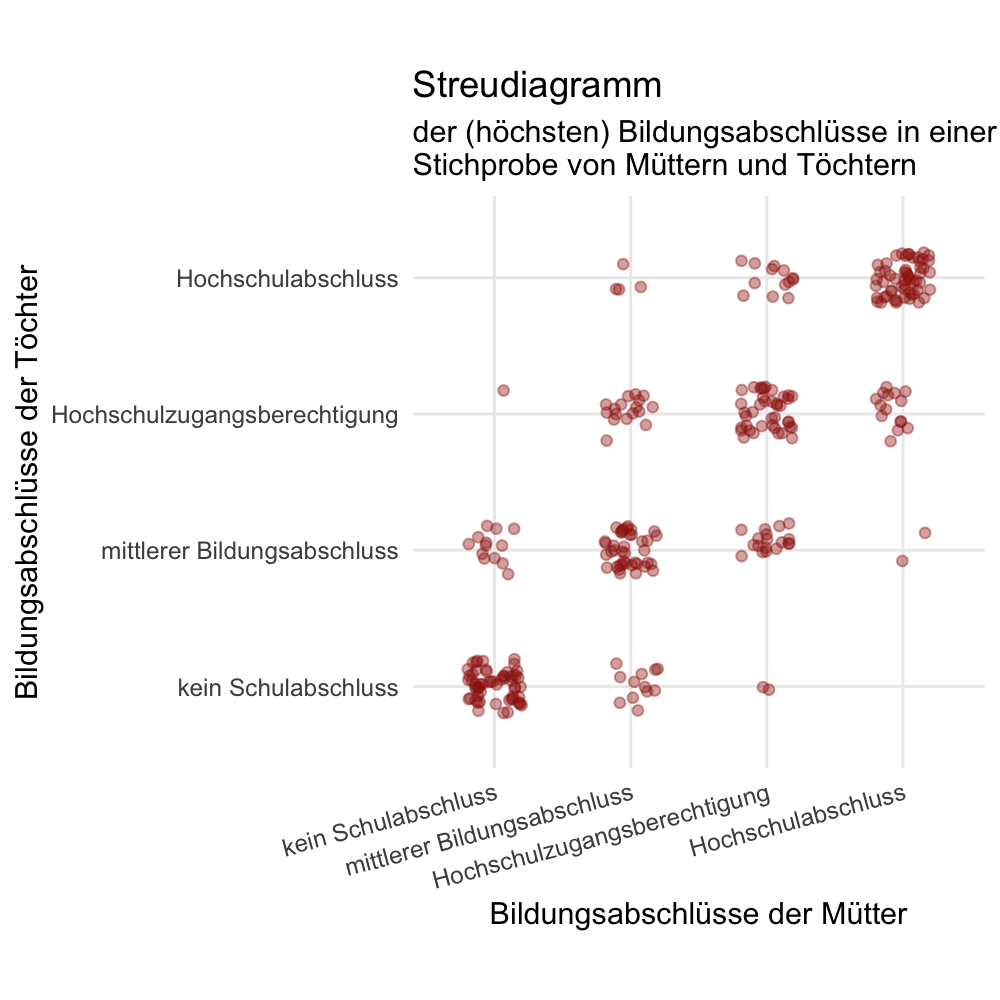

Angenommen ein Forscherteam erhebt in einem Land querschnittlich die höchsten Bildungsabschlüsse von 293 Müttern und deren ältesten Töchter und erhält die oben dargestellten Daten. Welche der folgenden Aussagen können anhand der Daten geschlussfolgert werden?

Die Bildungsabschlüsse der Mütter und der Töchter sind stark positiv korreliert.Die Bildungsabschlüsse der Mütter und der Töchter zeigen keine Assoziation.Die Bildungsabschlüsse der Väter und der Töchter sind schwach negativ korreliert.Höhere Bildung der Mütter **verursacht** höhere Bildung bei den Töchternz.Höhere Bildung der Väter **verursacht** niedrigere Bildung bei den Töchtern.

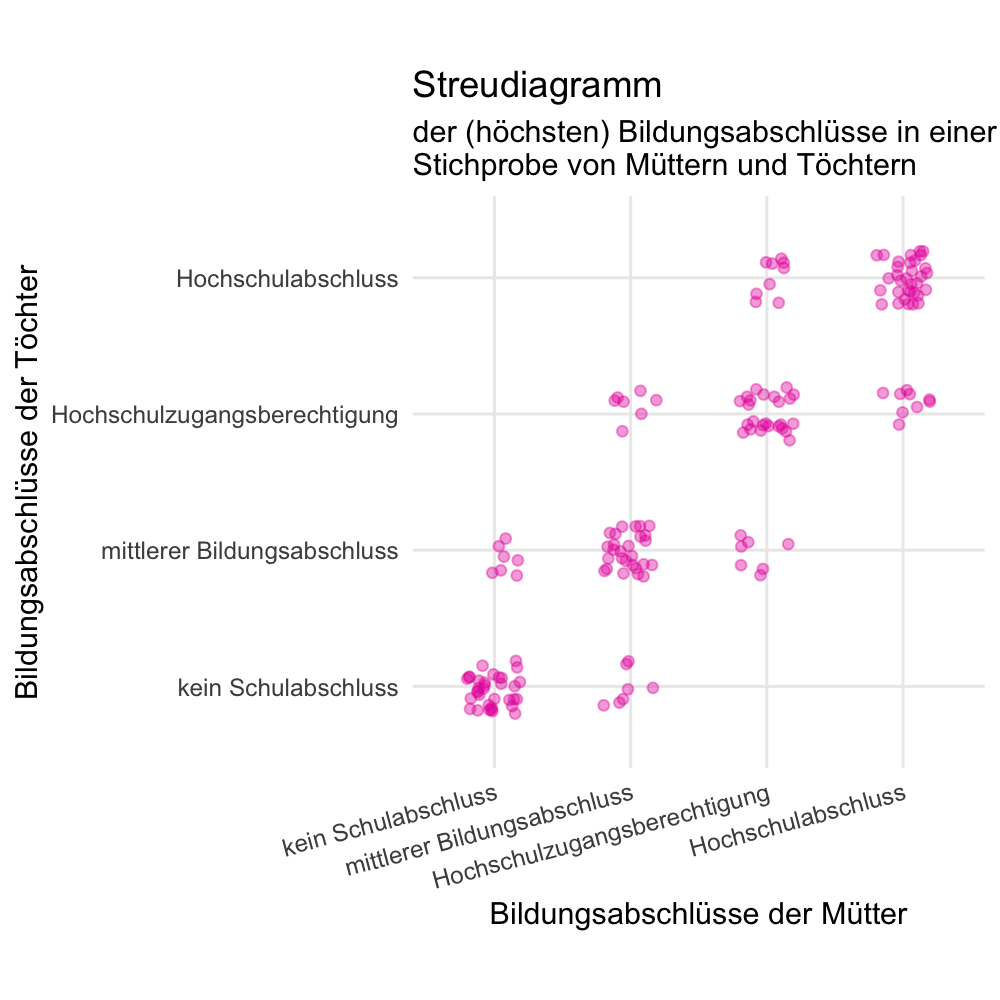

Angenommen ein Forscherteam erhebt in einem Land querschnittlich die höchsten Bildungsabschlüsse von 165 Müttern und deren ältesten Töchter und erhält die oben dargestellten Daten. Welche der folgenden Aussagen können anhand der Daten geschlussfolgert werden?

Die Bildungsabschlüsse der Mütter und der Töchter sind stark positiv korreliert.Die Bildungsabschlüsse der Mütter und der Töchter zeigen keine Assoziation.Die Bildungsabschlüsse der Väter und der Töchter sind schwach negativ korreliert.Höhere Bildung der Mütter **verursacht** höhere Bildung bei den Töchternz.Höhere Bildung der Väter **verursacht** niedrigere Bildung bei den Töchtern.

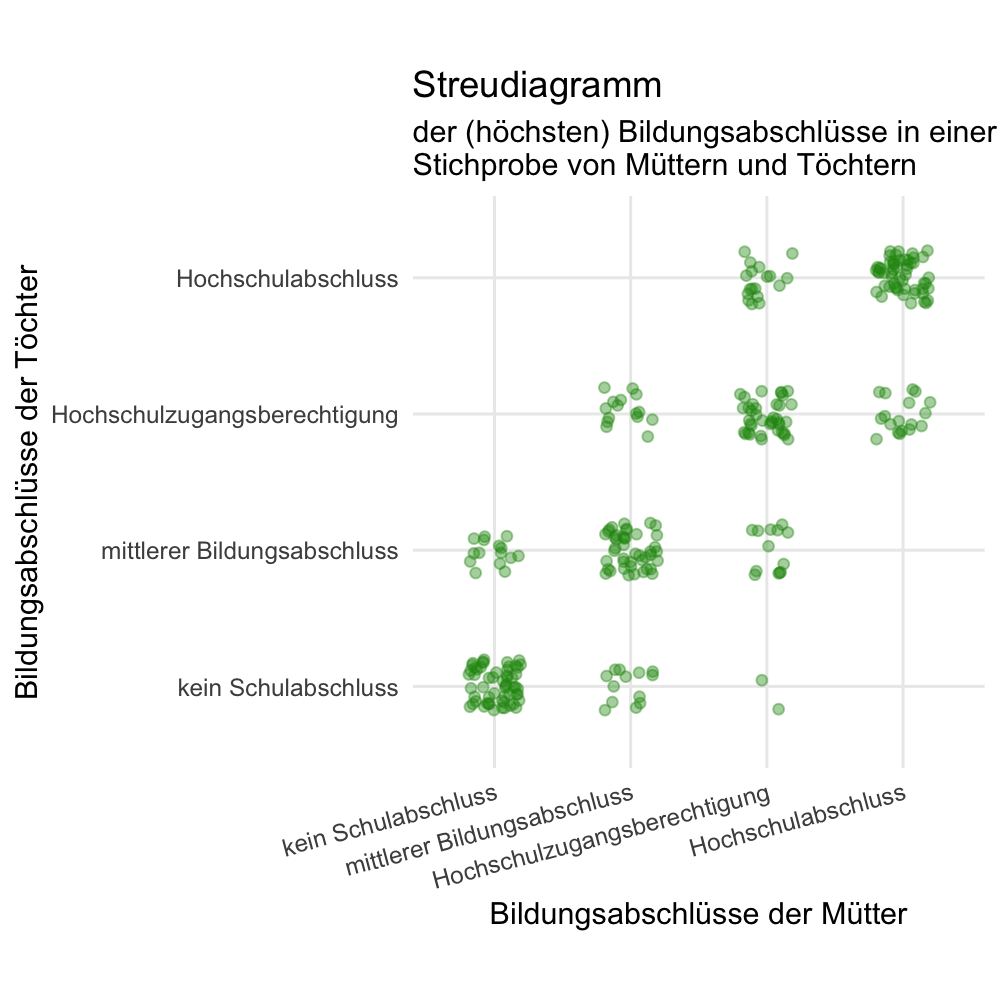

Angenommen ein Forscherteam erhebt in einem Land querschnittlich die höchsten Bildungsabschlüsse von 289 Müttern und deren ältesten Töchter und erhält die oben dargestellten Daten. Welche der folgenden Aussagen können anhand der Daten geschlussfolgert werden?

Die Bildungsabschlüsse der Mütter und der Töchter sind stark positiv korreliert.Die Bildungsabschlüsse der Mütter und der Töchter zeigen keine Assoziation.Die Bildungsabschlüsse der Väter und der Töchter sind schwach negativ korreliert.Höhere Bildung der Mütter **verursacht** höhere Bildung bei den Töchternz.Höhere Bildung der Väter **verursacht** niedrigere Bildung bei den Töchtern.

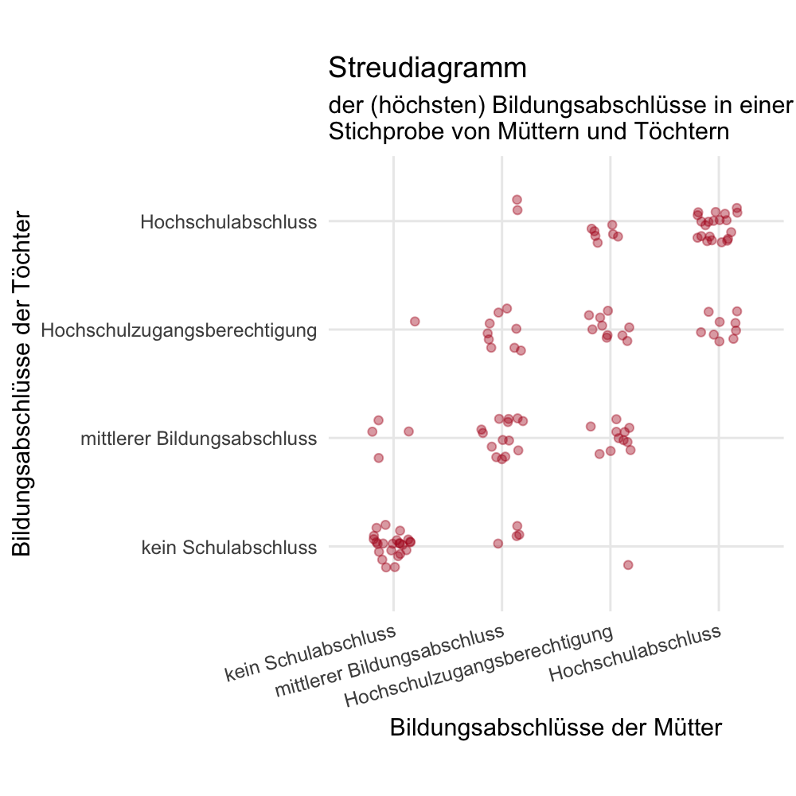

Angenommen ein Forscherteam erhebt in einem Land querschnittlich die höchsten Bildungsabschlüsse von 117 Müttern und deren ältesten Töchter und erhält die oben dargestellten Daten. Welche der folgenden Aussagen können anhand der Daten geschlussfolgert werden?

Die Bildungsabschlüsse der Mütter und der Töchter sind stark positiv korreliert.Die Bildungsabschlüsse der Mütter und der Töchter zeigen keine Assoziation.Die Bildungsabschlüsse der Väter und der Töchter sind schwach negativ korreliert.Höhere Bildung der Mütter **verursacht** höhere Bildung bei den Töchternz.Höhere Bildung der Väter **verursacht** niedrigere Bildung bei den Töchtern.

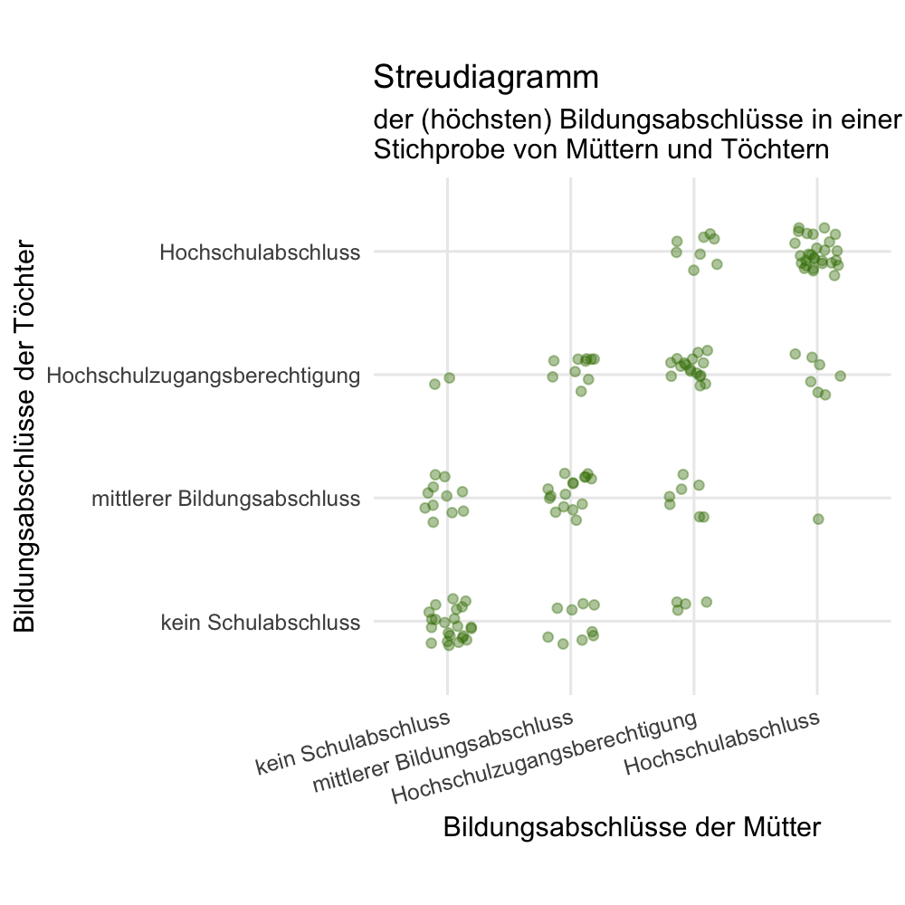

Angenommen ein Forscherteam erhebt in einem Land querschnittlich die höchsten Bildungsabschlüsse von 143 Müttern und deren ältesten Töchter und erhält die oben dargestellten Daten. Welche der folgenden Aussagen können anhand der Daten geschlussfolgert werden?

Die Bildungsabschlüsse der Mütter und der Töchter sind stark positiv korreliert.Die Bildungsabschlüsse der Mütter und der Töchter zeigen keine Assoziation.Die Bildungsabschlüsse der Väter und der Töchter sind schwach negativ korreliert.Höhere Bildung der Mütter **verursacht** höhere Bildung bei den Töchternz.Höhere Bildung der Väter **verursacht** niedrigere Bildung bei den Töchtern.

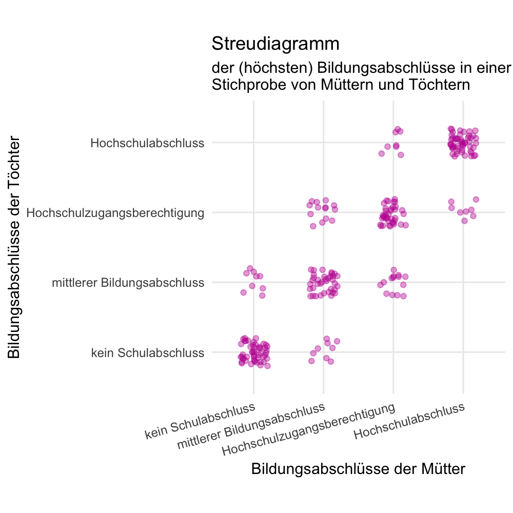

Angenommen ein Forscherteam erhebt in einem Land querschnittlich die höchsten Bildungsabschlüsse von 241 Müttern und deren ältesten Töchter und erhält die oben dargestellten Daten. Welche der folgenden Aussagen können anhand der Daten geschlussfolgert werden?

Die Bildungsabschlüsse der Mütter und der Töchter sind stark positiv korreliert.Die Bildungsabschlüsse der Mütter und der Töchter zeigen keine Assoziation.Die Bildungsabschlüsse der Väter und der Töchter sind schwach negativ korreliert.Höhere Bildung der Mütter **verursacht** höhere Bildung bei den Töchternz.Höhere Bildung der Väter **verursacht** niedrigere Bildung bei den Töchtern.

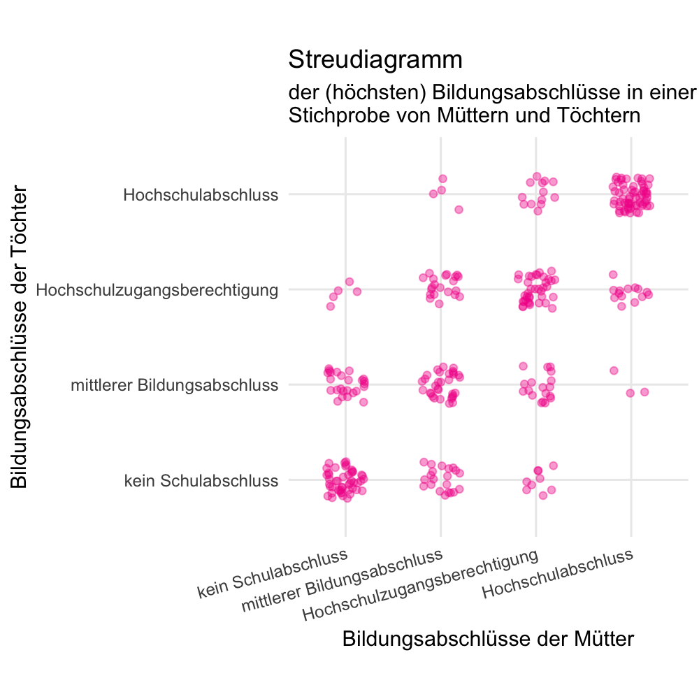

Angenommen ein Forscherteam erhebt in einem Land querschnittlich die höchsten Bildungsabschlüsse von 313 Müttern und deren ältesten Töchter und erhält die oben dargestellten Daten. Welche der folgenden Aussagen können anhand der Daten geschlussfolgert werden?

Die Bildungsabschlüsse der Mütter und der Töchter sind stark positiv korreliert.Die Bildungsabschlüsse der Mütter und der Töchter zeigen keine Assoziation.Die Bildungsabschlüsse der Väter und der Töchter sind schwach negativ korreliert.Höhere Bildung der Mütter **verursacht** höhere Bildung bei den Töchternz.Höhere Bildung der Väter **verursacht** niedrigere Bildung bei den Töchtern.

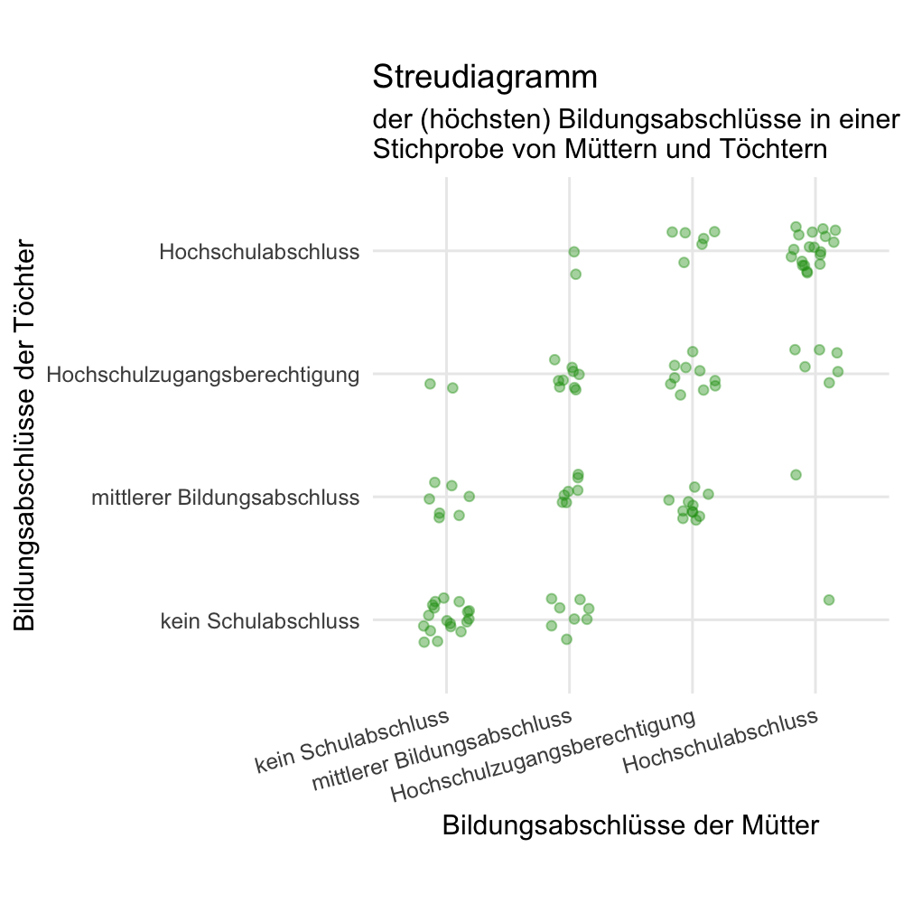

Angenommen ein Forscherteam erhebt in einem Land querschnittlich die höchsten Bildungsabschlüsse von 107 Müttern und deren ältesten Töchter und erhält die oben dargestellten Daten. Welche der folgenden Aussagen können anhand der Daten geschlussfolgert werden?

Die Bildungsabschlüsse der Mütter und der Töchter sind stark positiv korreliert.Die Bildungsabschlüsse der Mütter und der Töchter zeigen keine Assoziation.Die Bildungsabschlüsse der Väter und der Töchter sind schwach negativ korreliert.Höhere Bildung der Mütter **verursacht** höhere Bildung bei den Töchternz.Höhere Bildung der Väter **verursacht** niedrigere Bildung bei den Töchtern.

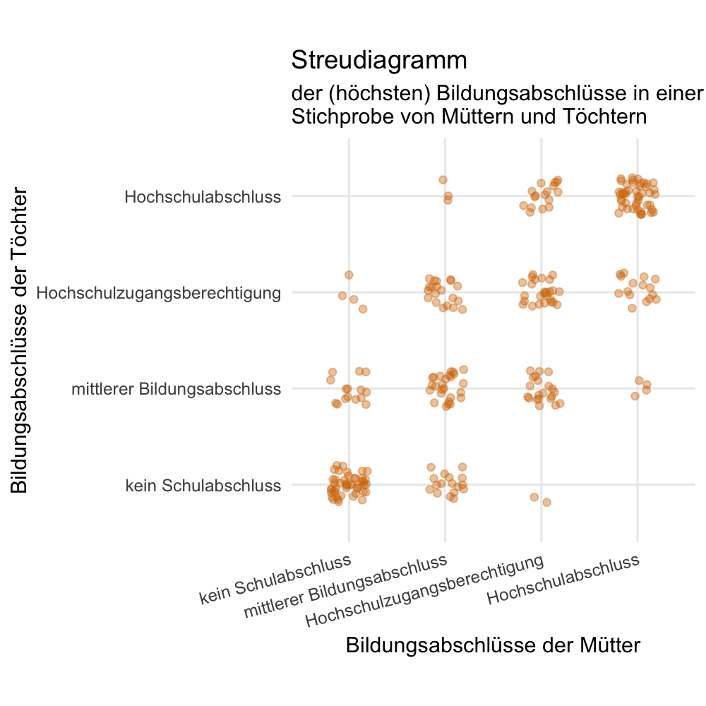

Angenommen ein Forscherteam erhebt in einem Land querschnittlich die höchsten Bildungsabschlüsse von 265 Müttern und deren ältesten Töchter und erhält die oben dargestellten Daten. Welche der folgenden Aussagen können anhand der Daten geschlussfolgert werden?

Die Bildungsabschlüsse der Mütter und der Töchter sind stark positiv korreliert.Die Bildungsabschlüsse der Mütter und der Töchter zeigen keine Assoziation.Die Bildungsabschlüsse der Väter und der Töchter sind schwach negativ korreliert.Höhere Bildung der Mütter **verursacht** höhere Bildung bei den Töchternz.Höhere Bildung der Väter **verursacht** niedrigere Bildung bei den Töchtern.

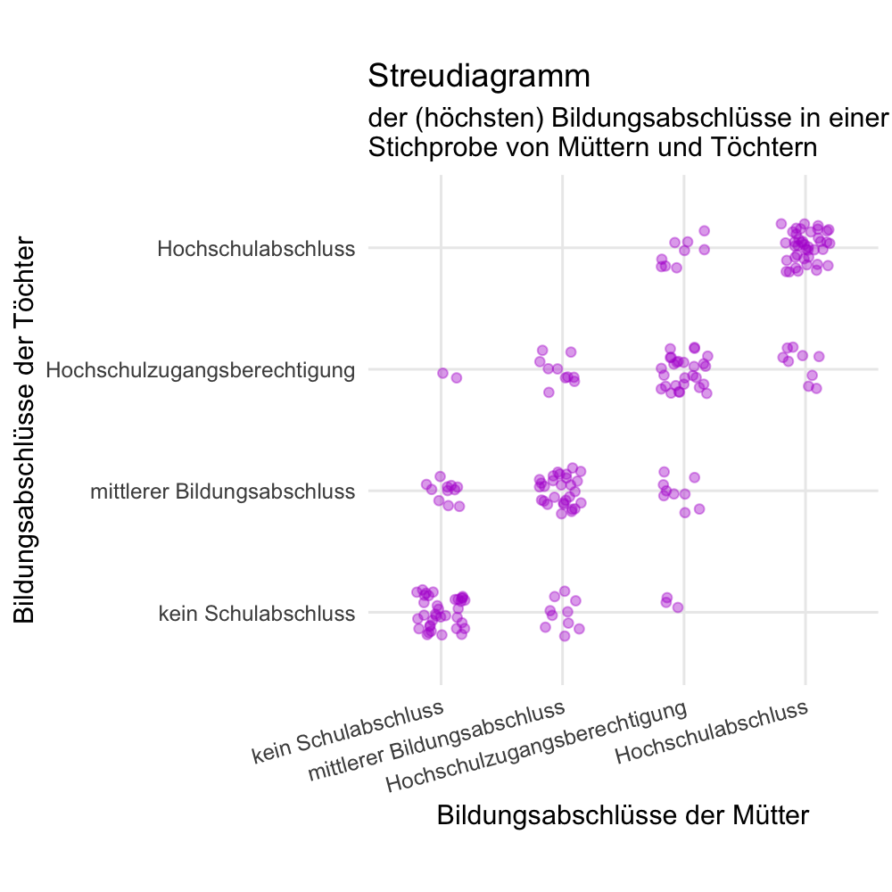

Angenommen ein Forscherteam erhebt in einem Land querschnittlich die höchsten Bildungsabschlüsse von 197 Müttern und deren ältesten Töchter und erhält die oben dargestellten Daten. Welche der folgenden Aussagen können anhand der Daten geschlussfolgert werden?

Die Bildungsabschlüsse der Mütter und der Töchter sind stark positiv korreliert.Die Bildungsabschlüsse der Mütter und der Töchter zeigen keine Assoziation.Die Bildungsabschlüsse der Väter und der Töchter sind schwach negativ korreliert.Höhere Bildung der Mütter **verursacht** höhere Bildung bei den Töchternz.Höhere Bildung der Väter **verursacht** niedrigere Bildung bei den Töchtern.

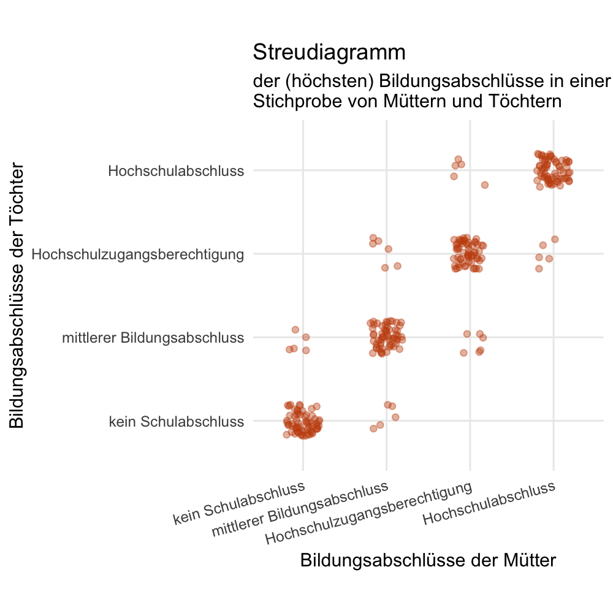

Angenommen ein Forscherteam erhebt in einem Land querschnittlich die höchsten Bildungsabschlüsse von 287 Müttern und deren ältesten Töchter und erhält die oben dargestellten Daten. Welche der folgenden Aussagen können anhand der Daten geschlussfolgert werden?

Die Bildungsabschlüsse der Mütter und der Töchter sind stark positiv korreliert.Die Bildungsabschlüsse der Mütter und der Töchter zeigen keine Assoziation.Die Bildungsabschlüsse der Väter und der Töchter sind schwach negativ korreliert.Höhere Bildung der Mütter **verursacht** höhere Bildung bei den Töchternz.Höhere Bildung der Väter **verursacht** niedrigere Bildung bei den Töchtern.

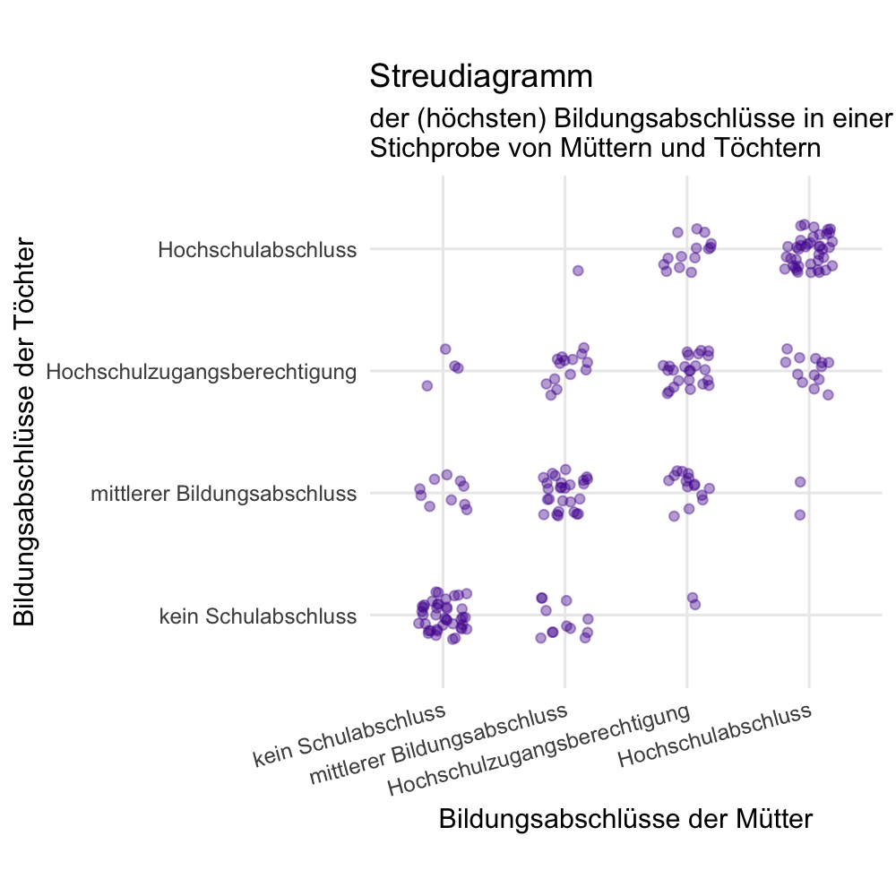

Angenommen ein Forscherteam erhebt in einem Land querschnittlich die höchsten Bildungsabschlüsse von 219 Müttern und deren ältesten Töchter und erhält die oben dargestellten Daten. Welche der folgenden Aussagen können anhand der Daten geschlussfolgert werden?

Die Bildungsabschlüsse der Mütter und der Töchter sind stark positiv korreliert.Die Bildungsabschlüsse der Mütter und der Töchter zeigen keine Assoziation.Die Bildungsabschlüsse der Väter und der Töchter sind schwach negativ korreliert.Höhere Bildung der Mütter **verursacht** höhere Bildung bei den Töchternz.Höhere Bildung der Väter **verursacht** niedrigere Bildung bei den Töchtern.

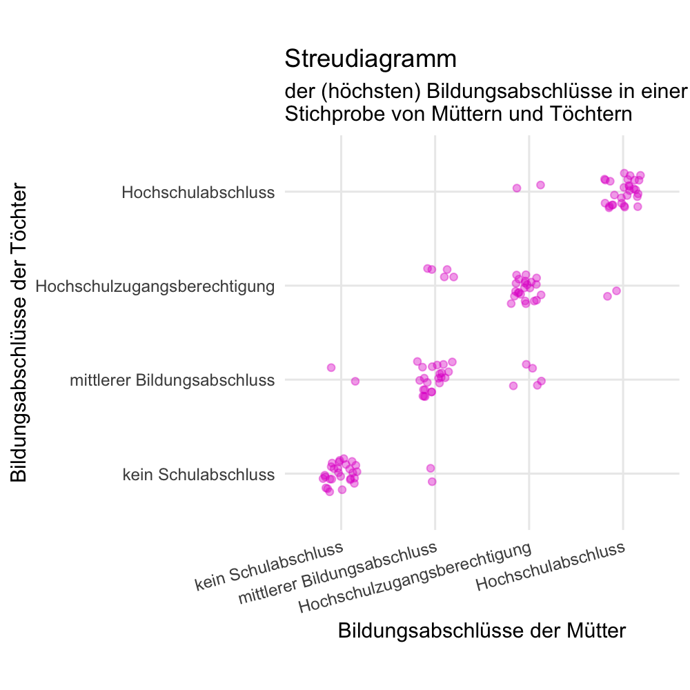

Angenommen ein Forscherteam erhebt in einem Land querschnittlich die höchsten Bildungsabschlüsse von 121 Müttern und deren ältesten Töchter und erhält die oben dargestellten Daten. Welche der folgenden Aussagen können anhand der Daten geschlussfolgert werden?

Die Bildungsabschlüsse der Mütter und der Töchter sind stark positiv korreliert.Die Bildungsabschlüsse der Mütter und der Töchter zeigen keine Assoziation.Die Bildungsabschlüsse der Väter und der Töchter sind schwach negativ korreliert.Höhere Bildung der Mütter **verursacht** höhere Bildung bei den Töchternz.Höhere Bildung der Väter **verursacht** niedrigere Bildung bei den Töchtern.

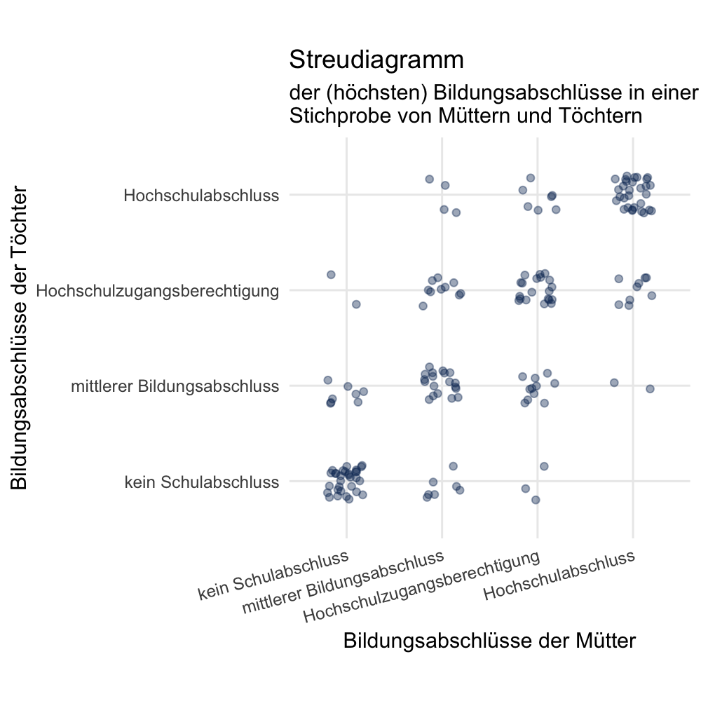

Angenommen ein Forscherteam erhebt in einem Land querschnittlich die höchsten Bildungsabschlüsse von 163 Müttern und deren ältesten Töchter und erhält die oben dargestellten Daten. Welche der folgenden Aussagen können anhand der Daten geschlussfolgert werden?

Die Bildungsabschlüsse der Mütter und der Töchter sind stark positiv korreliert.Die Bildungsabschlüsse der Mütter und der Töchter zeigen keine Assoziation.Die Bildungsabschlüsse der Väter und der Töchter sind schwach negativ korreliert.Höhere Bildung der Mütter **verursacht** höhere Bildung bei den Töchternz.Höhere Bildung der Väter **verursacht** niedrigere Bildung bei den Töchtern.